# Practical Machine Learning Project

## **Executive Summary**

- The project involved a five-factor classification and prediction problem.
- The processed raw training data was split into a Training and a Validation set. Models learned on the former and were tested on the latter.
- Raw data drawn from the Weight Lifting Exercise Dataset were examined. A number of computed summary variables not present in the Testing dataset were omitted. In addition, it *is shown* that certain time-related and bookkeeping variables “leak” information on the specifics of the protocol – while these are likely powerful predictors for the Testing set, they could not be generalized to any other context and hence were removed. The problematic variables/columns were removed from the Training, Validation, and Testing sets.
- For each of several classification methods, tuning and some other parameters were adjusted to roughly optimize the results. Computationally undemanding approaches (CART using rpart, K-nearest neighbor approaches under caret) provided were inferior to Generalized Boosted Regression Modeling (gam); Random Forest models were slightly better at comparable computation expenditures.

## **Introduction**

For brevity, we assume that general motivations and methods of “Qualitative Activity Recognition of Weight Lifting Exercises”, Velloso, Bulling *et al.*, are known to the reader. A few details are recapitulated. Six volunteers performed a particular weightlifting exercise (sets of 10 reps) in a specified correct manner and in four distinct incorrect ways. Movements were captured using an array of four motion sensors – affixed to the subjects’ gloves, armbands, and belts, as well as to the dumbbell. Readings were recorded in time series employing a range of “sliding window” sizes.

## **Raw Data**

At every time point movement along three spacial axis for each of the four sensors provides 36 variables. Roll, pitch, and yaw were derived for each sensor at each time point (12 variables). Then, for each time window, eight statistical features were calculated for each of the twelve derived variables (96 “statistical” variables). The raw training dataset contains 19622 time point observations of at least the direct and derived variables. Prior to any analysis it was partitioned 70:30 into analysis Training and Validation sets.

```r
library(caret)
library(tree)
library(rpart)
library(gbm)
library(ggplot2)
library(plyr)
library(randomForest)
```

```r
raw.training <- read.csv("pml-training.csv")
raw.testing <- read.csv("pml-testing.csv")

set.seed(37360)
inTrain <- createDataPartition(raw.training$classe, p=0.70, list = FALSE)
rawTrain <- raw.training[inTrain,]
rawValid <- raw.training[-inTrain,]
```

## **Pre-Processing Considerations**

### **Problematic Predictors**

To illustrate the deceptive folly of retaining time and protocol data, I constructed a subset of the raw (but partitioned) training set — retaining only “classe” and the predictors related to user, time and time window status.

```r
testFit1 <- train(classe ~ user_name + raw_timestamp_part_1 + raw_timestamp_part_2 + cvtd_timestamp + num_window, method = "gbm", data = rawTrain, verbose = F, trControl = trainControl(method = "cv", number = 5))
```

An unoptimized gbm model predicted the class with 0.2% training set error and **0.4% validation set error!** Yet the model employs no sensor data and would be completely ungeneralizable.

```r
predTest1 <- predict(testFit1, newdata = rawTrain)
predVal1 <- predict(testFit1, newdata = rawValid)

## Test Set Error
confusionMatrix(predTest1, rawTrain$classe)$overall[1:2]
```

```
## Accuracy    Kappa
##   0.9981   0.9976
```

```r
## Validation Set Error
confusionMatrix(predVal1, rawValid$classe)$overall[1:2]
```

```
## Accuracy    Kappa
##   0.9963   0.9953
```

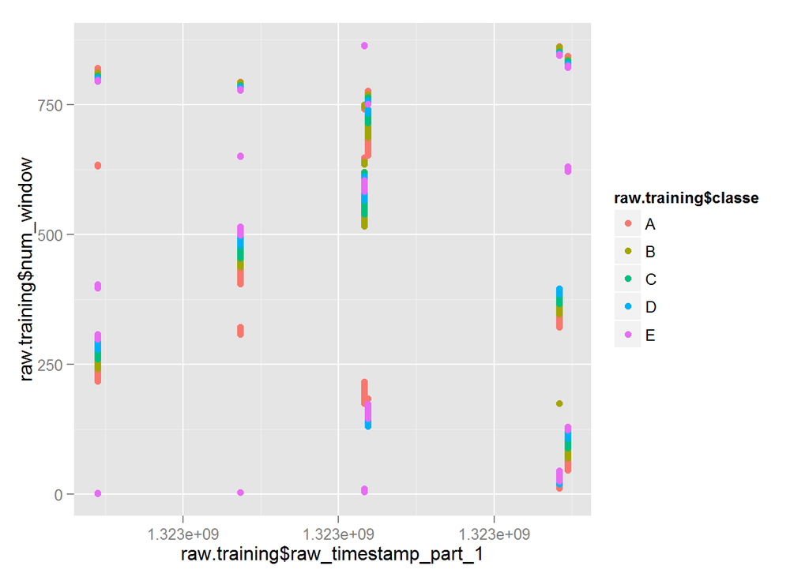

```r
qplot(raw.training$raw_timestamp_part_1, raw.training$num_window, color = raw.training$classe)
```

### **Elimination of Spurious and Problematic Variables**

The timestamp, window variables, and all of the statistical variables were removed to create the processed Training, Validation, and Testing datasets. Username is retained (and used for *some* models) — while those particular factors would not be useful in another context, it might be reasonable to employ some identifier relating sensor data to subject. However, models that either omit username or rely very little on that variable will be favored.

```r
sel <- c(2, 8:11, 37:49, 60:68, 85:86, 102, 113:124, 140, 151:160)
Train <- rawTrain[, sel]
Valid <- rawValid[, sel]
```

## **Models - Training the Processed Dataset**

### **CART – Classification and Regression Trees**

I first explored a series of CART models using the rpart package, with “gini” as the splitting index and the complexity parameter “cp” ranging from 0.05 to 0. Sparse models had little predictive power, while the best result (cp = 0) used 45 variables to provide moderate accuracy (see below).

```r
set.seed(74295)
rpartFit2 <- rpart(classe ~., data = Train, method = "class", parms = list(split="ginni"), control = rpart.control(cp = 0.00))
rpartPred2 <- predict(rpartFit2, newdata = Train, type = "class")
rpartVal2 <- predict(rpartFit2, newdata = Valid, type = "class")

## Training Set Accuracy
confusionMatrix(rpartPred2, Train$classe)$overall[1:2]
```

```
## Accuracy    Kappa
##   0.9591   0.9483
```

```r
##Validation Set Accuracy
confusionMatrix(rpartVal2, Valid$classe)$overall[1:2]
```

```
## Accuracy    Kappa
##   0.9269   0.9076
```

### **KNN Models**

Several KNN models were trained using the knn method under caret. For simplicity, the “user name” factor variable was omitted. The models were not particularly accurate, as determined by validation set accuracy. A typical example follows.

```r
trainD <- Train[,-1]
validD <- Valid[, -1]

set.seed(84934)
ctrl <- trainControl(method = "repeatedcv", repeats = 5)
knnFit1 <- train(classe~., data = trainD, method = "knn", tuneLength = 12, trControl = ctrl)
```

Accuracy was used to select the optimal model using the largest value. The final value used for the model was k = 5.

###### **Training Set Accuracy**

| Accuracy | Kappa |
| --- | --- |
| 0.9561767 | 0.9445519 |

###### **Validation Set Accuracy**

| Accuracy | Kappa |
| --- | --- |
| 0.9045030 | 0.8791939 |

### **Stochastic Gradient Boosting**

Stochastic Gradient Boosting (gbm) was used to train several models. All gbm and random forest models were optimized using “cv” or “adaptive cv” methods, as computations that employed bootstrap techniques were too time-consuming. For the gbm model below, estimated training set error is 3.9% (mean of errors from ten CV runs); misclassification error on the training set is 2.7%. Misclassification error on the validation set is 4.3%. Predictive power of the gbm models, while formidable, are eclipsed by random forest models.

```r
set.seed(87094)
sgbTest1 <- train(classe ~ ., method = "gbm", data = Train, verbose = F, trControl = trainControl(method = "cv", number = 10))
#sgbTest1
predsgbTrain1 <- predict(sgbTest1, newdata = Train)
predsgbVal1 <- predict(sgbTest1, newdata = Valid)
sgbCMTrain1 <- confusionMatrix(predsgbTrain1, Train$classe)
sgbCMVal1 <- confusionMatrix(predsgbVal1, Valid$classe)
mean(sgbTest1$resample$Accuracy)
```

```
## [1] 0.9613
```

```r
## Training Set Accuracy
postResample(predsgbTrain1, Train$classe)
```

```
## Accuracy    Kappa
##   0.9731   0.9660
```

```r
## Validation Set Accuracy
sgbCMVal1$table
```

```
##           Reference
## Prediction    A    B    C    D    E
##          A 1643   37    0    1    1
##          B   18 1065   36    1    8
##          C   11   37  974   37   16
##          D    1    0   13  915   21
##          E    1    0    3   10 1036
```

```r
postResample(predsgbVal1, Valid$classe)
```

```
## Accuracy    Kappa
##   0.9572   0.9458
```

## **Random Forest Models**

Several random forest models were trained; four are included below. All of the “perfectly predicted” the training set classification, and all were greater than 99% accurate classifying the validation set.

```r
set.seed(68678)

rfTrain1 <- train(classe ~ ., method = "rf", data = Train, importance = T, trControl = trainControl(method = "cv", number = 10))

predrfTrain1 <- predict(rfTrain1, newdata = Train)
predrfVal1 <- predict(rfTrain1, newdata = Valid)
rfCMTrain1 <- confusionMatrix(predrfTrain1, Train$classe)
rfCMVal1 <- confusionMatrix(predrfVal1, Valid$classe)

## Training Set Accuracy
## Accuracy    Kappa
##        1        1

## Validation Set Accuracy
##  Accuracy     Kappa
## 0.9913339 0.9890383
```

```r
set.seed(94388)


ctrl2 <- trainControl(method = "adaptive_cv", repeats = 5, verboseIter = FALSE)
rfTrain2 <- train(classe ~ ., method = "rf", data = Train, importance = T, trControl = ctrl2)
predrfTrain2 <- predict(rfTrain2, newdata = Train)
predrfVal2 <- predict(rfTrain2, newdata = Valid)
rfCMTrain2 <- confusionMatrix(predrfTrain2, Train$classe)
rfCMVal2 <- confusionMatrix(predrfVal2, Valid$classe)

## Training Set Accuracy
rfCMTrain2$table
```

```
##           Reference
## Prediction    A    B    C    D    E
##          A 3906    0    0    0    0
##          B    0 2658    0    0    0
##          C    0    0 2396    0    0
##          D    0    0    0 2252    0
##          E    0    0    0    0 2525
```

```r
postResample(predrfTrain2, Train$classe)
```

```
## Accuracy    Kappa
##        1        1
```

```r
## Validation Set Accuracy
rfCMVal2$table
```

```
##           Reference
## Prediction    A    B    C    D    E
##          A 1667    8    0    0    0
##          B    3 1126    5    1    0
##          C    3    4 1020   16    1
##          D    0    1    1  944    2
##          E    1    0    0    3 1079
```

```r
postResample(predrfVal2, Valid$classe)
```

```
## Accuracy    Kappa
##   0.9917   0.9895
```

```r
TestPred3 <- predict(rfTrain2, newdata = Test)
# TestPred3
```

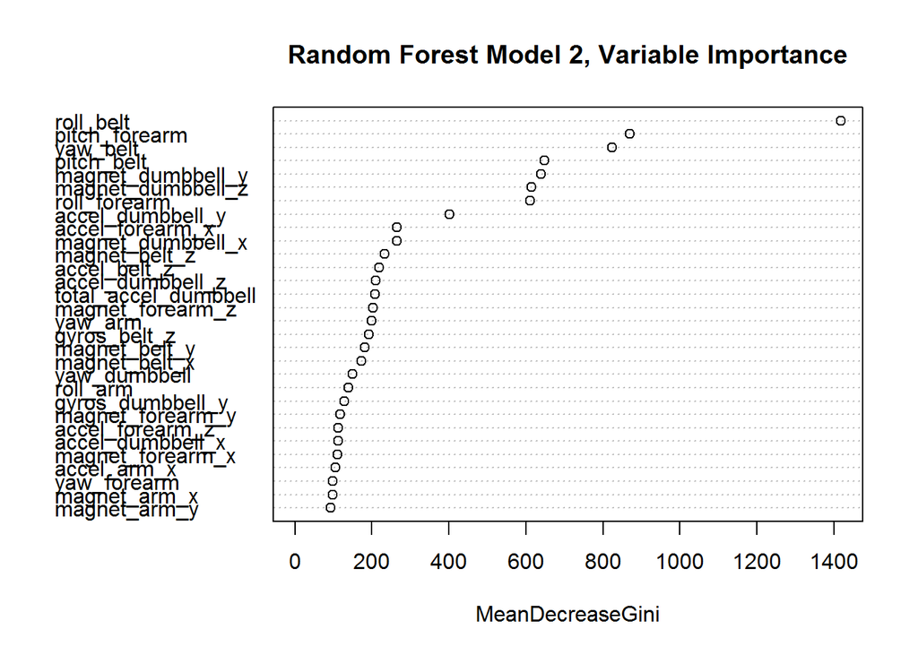

```r
rfT2fM <- rfTrain2$finalModel
varImpPlot(rfT2fM, sort=TRUE, n.var=min(30, nrow(rfT2fM$importance)), type=2, scale=TRUE, main ="Random Forest Model 2, Variable Importance")
```

```r
set.seed(30497)
rfTrain3 <- randomForest(Train[,-53], Train$classe, ntree=2048, importance=TRUE, do.trace=FALSE)
```

```r
set.seed(9233)

ctrl2 <- trainControl(method = "adaptive_cv", repeats = 5, verboseIter = FALSE)
rfTrain4 <- train(classe ~ ., method = "rf", data = Train[,-1], importance = T, trControl = ctrl2)
predrfTrain4 <- predict(rfTrain4, newdata = Train)
predrfVal4 <- predict(rfTrain4, newdata = Valid)
rfCMT4 <- confusionMatrix(predrfTrain4, Train$classe)
rfCMV4 <- confusionMatrix(predrfVal4, Valid$classe)


## Training Set Accuracy
rfCMT4$table
```

```
##           Reference
## Prediction    A    B    C    D    E
##          A 3906    0    0    0    0
##          B    0 2658    0    0    0
##          C    0    0 2396    0    0
##          D    0    0    0 2252    0
##          E    0    0    0    0 2525
```

```r
postResample(predrfTrain4, Train$classe)
```

```
## Accuracy    Kappa
##        1        1
```

```r
## Validation Set Accuracy
rfCMV4$table
```

```
##           Reference
## Prediction    A    B    C    D    E
##          A 1669    9    0    0    0
##          B    2 1126    7    0    0
##          C    3    4 1017   16    0
##          D    0    0    2  945    2
##          E    0    0    0    3 1080
```

```r
postResample(predrfVal4, Valid$classe)
```

```
## Accuracy    Kappa
##   0.9918   0.9897
```

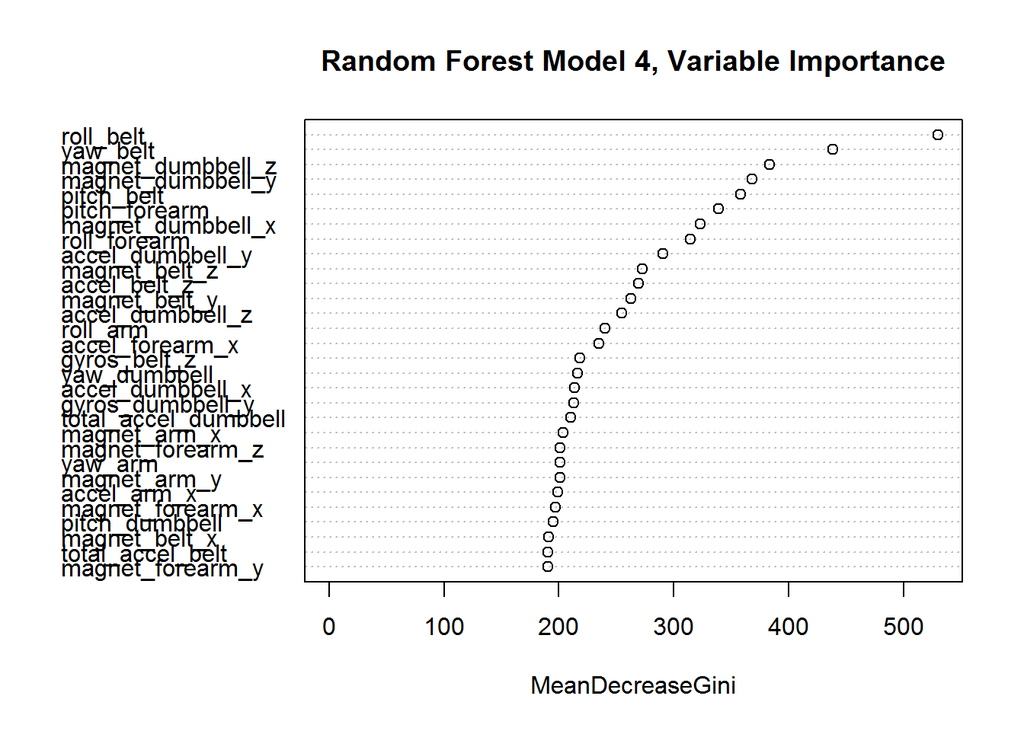

```r
rfT4fM <- rfTrain4$finalModel
varImpPlot(rfT4fM, sort=TRUE, type=2, scale=TRUE, main ="Random Forest Model 4, Variable Importance")
```

## **Summary of Models**

*Accuracy (%)*

```
##                 Training.Set Validation.Set
## rpart (best)           0.959          0.927
## knn(knnFit1)           0.956          0.904
## gbm                    0.973          0.957
## random forest 1        1.000          0.991
## random forest 2        1.000          0.992
## random forest 3        1.000          0.994
## random forest 4        1.000          0.992
```